# R Notes on Correlation, Association Measures, etc.

Luisa M. Mimmi

Last run: September 29, 2019

# CORRELATION AND HOW TO MEASURE IT DEPENDING ON TYPE OF VARIABLE(S)

### Set UP

```r
# I am  executing bc it for the blog post
knitr::opts_chunk$set(eval = TRUE,
                             echo = TRUE,
                             tidy = FALSE,
                             results='hide',
                             message = FALSE,
                             warning = FALSE , fig.show='asis', fig.align='center',
                             fig.width=6, fig.height=6)

# POV is where .toml is?
load(here::here( "AC_ppl_fakeID.Rdata"), verbose = T)
```

```
## Loading objects:
##   AC_ppl_fakeID
```

```r
if (!require("PerformanceAnalytics")) install.packages("PerformanceAnalytics")
if (!require("ggcorrplot")) install.packages("ggcorrplot")
if (!require("GGally")) install.packages("GGally") # Ext to ggplot2
if (!require("ggpubr")) install.packages("ggpubr")
if (!require("kableExtra")) install.packages("kableExtra")
if (!require("pander")) install.packages("pander")
```

## Between 2 CONTINUOUS variables

### Pearson correlation (r)

Pearson correlation (r) measures a linear dependence between 2 CONTINUOUS variables (x and y) / or 2 dichotomous var > It’s also known as a parametric correlation test because it depends to the distribution of the data. > The Pearson correlation evaluates the linear relationship between two continuous variables.

#### FORMULA

In the formula below,

= $x$ and $y$ are two vectors of length $n$ = $m_x$ and $m_y$ corresponds to the means of x and y, respectively.

$$r = \frac{\sum{(x-m_x)(y-m_y)}}{\sqrt{\sum(x-m_x)^2\sum(y-m_y)^2}}$$

The p-value (significance level) of the correlation can be determined :

by calculating the t value as follow:

$$t={\frac{r}{\sqrt{(1−r^2)}}}\sqrt{n−2}$$

In the case 2) the corresponding p-value is determined using t distribution table for df=n−2

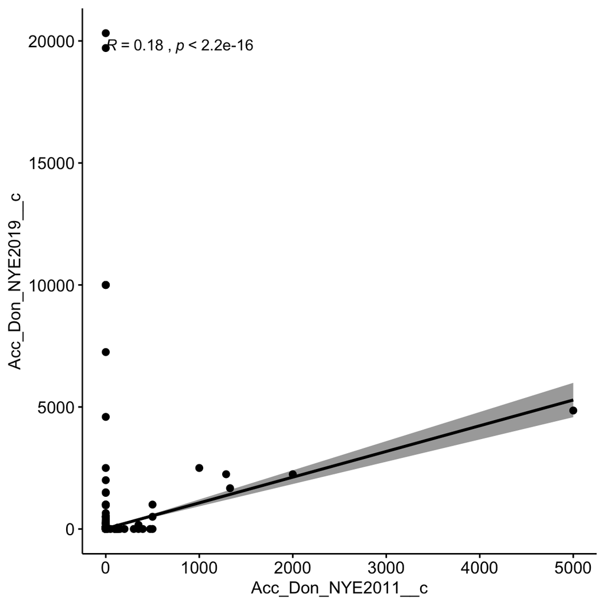

```r
# For example

# x = "Acc_Don_NYE2019__c"
# y = "Acc_Don_NYE2011__c"
cor(AC_ppl_fakeID$Acc_Don_NYE2011__c, AC_ppl_fakeID$Acc_Don_NYE2019__c,
     method = c("pearson" )) # 0.17
cor(AC_ppl_fakeID$Acc_Don_NYE2018__c, AC_ppl_fakeID$Acc_Don_NYE2019__c,
     method = c("pearson" )) # 0.68

# Pearson correlation test
res11 <- cor.test(AC_ppl_fakeID$Acc_Don_NYE2011__c, AC_ppl_fakeID$Acc_Don_NYE2019__c,
                        method = "pearson")
res11

res18 <- cor.test(AC_ppl_fakeID$Acc_Don_NYE2018__c, AC_ppl_fakeID$Acc_Don_NYE2019__c,
                        method = "pearson")
res18

# Visualize your data using scatter plots
library("ggpubr")
ggscatter(AC_ppl_fakeID, x = "Acc_Don_NYE2011__c", y = "Acc_Don_NYE2019__c",
             add = "reg.line", conf.int = TRUE,
             cor.coef = TRUE, cor.method = "pearson",
             xlab = "Acc_Don_NYE2011__c", ylab = "Acc_Don_NYE2019__c")
```

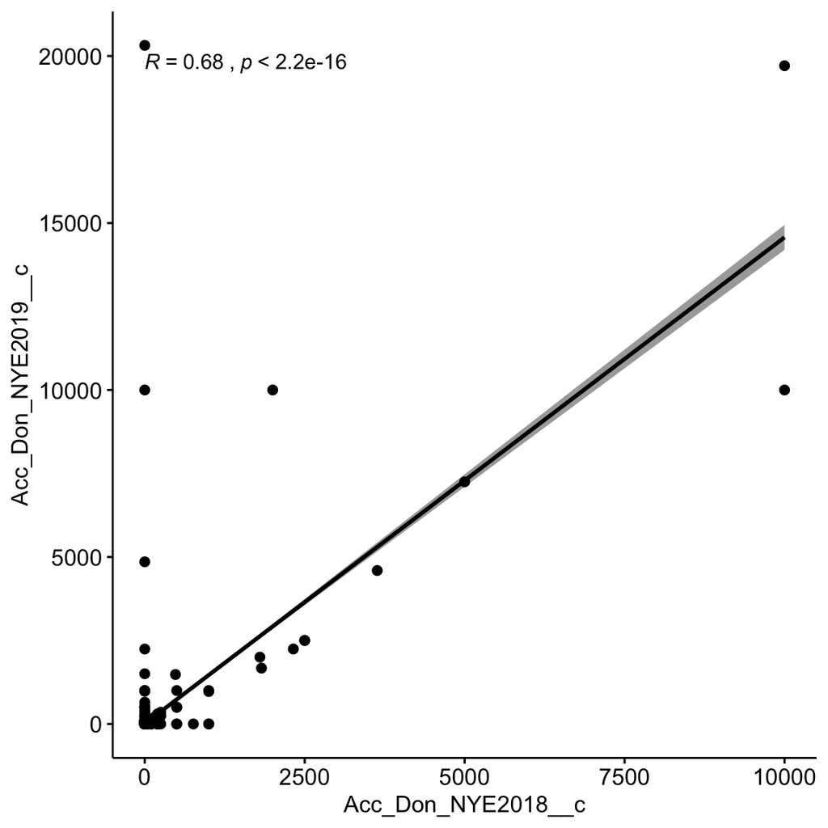

```r
library("ggpubr")
ggscatter(AC_ppl_fakeID, x = "Acc_Don_NYE2018__c", y = "Acc_Don_NYE2019__c",
             add = "reg.line", conf.int = TRUE,
             cor.coef = TRUE, cor.method = "pearson",
             xlab = "Acc_Don_NYE2018__c", ylab = "Acc_Don_NYE2019__c")
```

#### More Visualization

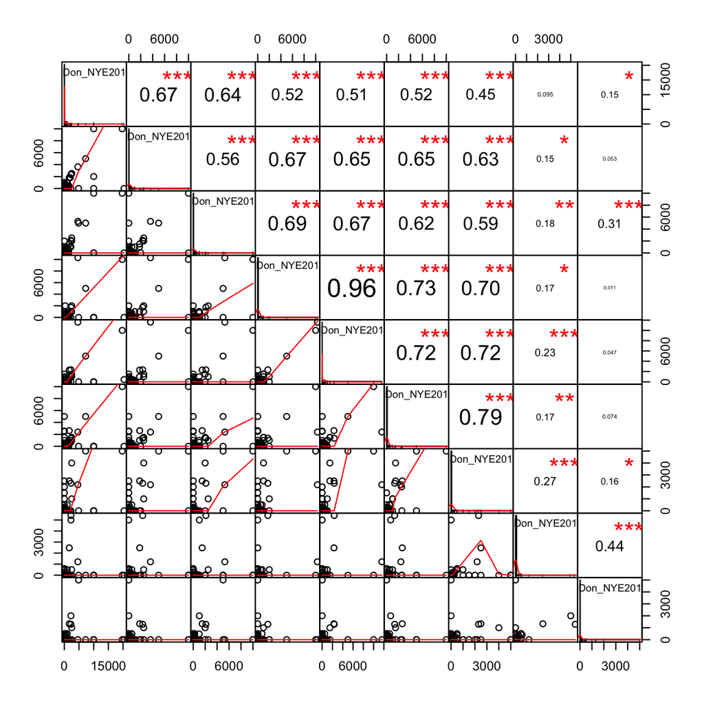

```r
# SELECT A FEW NUMER
data_numeric <- AC_ppl_fakeID[ , purrr::map_lgl(AC_ppl_fakeID, is.numeric)]

data_numeric2 <- data_numeric %>%
    dplyr::filter(Acc_Don_Tot >0) %>%
    dplyr::select( 4:12)

# === modo A)
library(PerformanceAnalytics)
cormat <- chart.Correlation(data_numeric2, histogram=TRUE, pch=19)
```

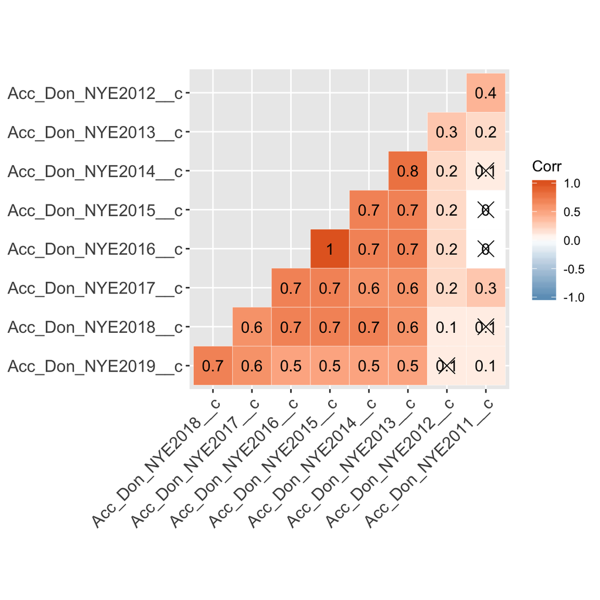

```r
# === modo B)
    # 1) Compute a matrix of correlation p-values
    library(ggcorrplot)
    p.mat <- cor_pmat(data_numeric2)
    p.mat

    # 2) Compute a correlation matrix
corr.mat <- round(cor(data_numeric2, use = "pairwise.complete.obs"), # USE everything", "all.obs", "complete.obs", "na.or.complete"
                        digits = 1)
corr.mat
    # 3) Visualize the correlation matrix
ggcorrplot(corr.mat , hc.order = F, type = "lower", method = "square", #method = "circle"
   outline.col = "white",
   ggtheme = ggplot2::theme_gray,
   colors = c("#6D9EC1", "white", "#E46726"),lab = TRUE, p.mat = p.mat)
```

```r
# === modo C)
library(GGally)
 GGally::ggcorr(data = data_numeric2 ,
    # geom object to use. Accepts either "tile", "circle", "text" or "blank"
    geom = "tile" , label = TRUE,   label_alpha = T, hjust = 0.9, layout.exp = 2
    )
```

[figure not shown]

## Between 2 ORDINAL, INTERVAL or RATIO variables (x and y)

### a) Spearman rank-order correlation

> The Spearman’s rank-order correlation is the nonparametric version of the Pearson product-moment correlation. Spearman’s correlation coefficient, (ρ, also signified by rs) measures the strength and direction of association between two ranked variables.

Also called `Spearman's rank-order correlation`

#### FORMULA

> add from [here](http://www.sthda.com/english/wiki/correlation-test-between-two-variables-in-r#what-is-correlation-test) …

Ordinal (growing class of Donor) vs ordinal (growing most recent email opened)

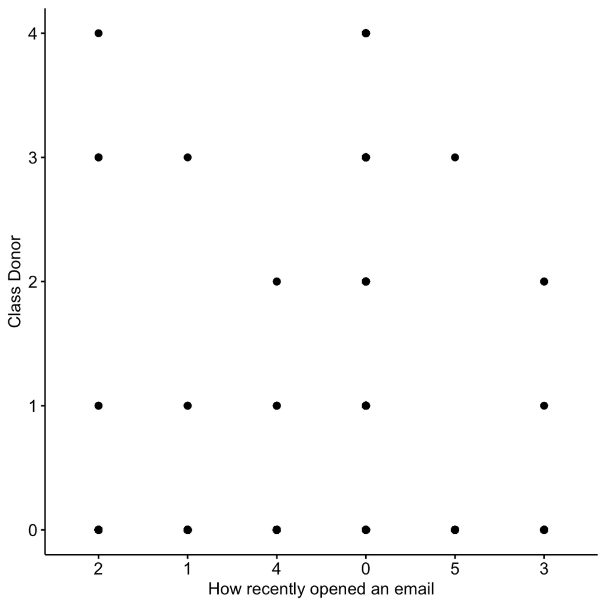

```r
# USING  DON CLASSES AS PER JOSES'
skimr::sorted_count(AC_ppl_fakeID$DonorClass) # ordine crescete (highere more generous)
# AND FACTOR RECENT OPEN EMAIL
skimr::sorted_count(AC_ppl_fakeID$EmLastMostRecent)# ordine crescete (higher more recent )
table(AC_ppl_fakeID$EmLastMostRecent, AC_ppl_fakeID$DonorClass)

# ============Spearman’s rho statistic

corr1 <- cor.test(AC_ppl_fakeID$DonorClass, as.numeric(AC_ppl_fakeID$EmLastMostRecent),  method = "spearman" )
corr1

# library("Hmisc")
# corr1b <- rcorr(AC_ppl3$Acc_Don_Tot, AC_ppl3$EmLastMostRecent,type = "spearman" )
# corr1b

library("ggpubr")
ggscatter(AC_ppl_fakeID, x = "EmLastMostRecent", y = "DonorClass",
          add = "reg.line", conf.int = TRUE,
          cor.coef = TRUE, cor.method = "pearson",
          xlab = "How recently opened an email", ylab = "Class Donor")
```

```r
# Very week negative correlation rho ~ -0.06094809
```

### b) Kendall tau

Kendall tau is another rank-based correlation coefficients (non-parametric) > The Kendall rank correlation coefficient or Kendall’s tau statistic is used to estimate a rank-based measure of association. This test may be used if the data do not necessarily come from a bivariate normal distribution.

The Kendall correlation method measures the correspondence between the ranking of x and y variables. The total number of possible pairings of x with y observations is n(n−1)/2, where n is the size of x and y.

The procedure is as follow: + Begin by ordering the pairs by the x values. If x and y are correlated, then they would have the same relative rank orders. + Now, for each yi, count the number of ${y_{j}}$ > ${y_{i}}$ (**concordant pairs (c)**) and the number of ${y_{j}}$<${y_{i}}$ (**discordant pairs (d)**).

#### FORMULA

Kendall correlation distance is defined as follow:

$$tau=\frac{n_{c}-n_{d}}{\frac{1}{2}n(n-1)}$$

Where ${n_{c}}$: total number of concordant pairs ${n_{d}}$: total number of discordant pairs ${n}$: size of x and y

> from [kendall](http://www.sthda.com/english/wiki/correlation-test-between-two-variables-in-r#what-is-correlation-test)

```r
corrKend <- cor.test(AC_ppl_fakeID$Acc_Don_Tot, as.numeric(AC_ppl_fakeID$EmLastMostRecent),  method = "kendall" )
corrKend
# Very week negative correlation tau ~ -0.09864503

corrKend2 <- cor.test(AC_ppl_fakeID$DonorClass, as.numeric(AC_ppl_fakeID$EmLastMostRecent),  method = "kendall" )
corrKend2
# Very week negative correlation tau ~ -0.05578083
```

## Between 2 CATEGORICAL variables

When data includes 2 categorical variables, the most common test for that association is going to be the **Chi Squared test for Independence** (sometimes called `Crosstabs`).

### Chi Squared test for Crosstabs with categorical variables

(*) Quickly check with `stats::ftable(..., exclude = c(NA, NaN), row.vars = NULL,col.vars = NULL)`

```r
# smaller
AC_red<- AC_ppl_fakeID %>%
    dplyr::select(IsDonor, HasEmail)



# Creating crosstabs for categorical variables

# Load data
ftable(AC_red)  # Makes "flat" table

ttab <- table(AC_red$IsDonor, AC_red$HasEmail)
# Call also get cell, row, and column %
# With rounding to get just 2 decimal places
# Multiplied by 100 to make %
round(prop.table(ttab, 1), 2) * 100 # row %
round(prop.table(ttab, 2), 2) * 100 # column %
round(prop.table(ttab), 2) * 100    # cell %

# Chi-squared test
# (Test of association to see if
# H0: the 2 cat var (Class & Survived) are independent
# H1: the 2 cat var are correlated in __some way__


tchi <- chisq.test(ttab)
tchi
# RESULTS  p-value < 0.00000000000000022 --> We reject the null hypothesis that the class is independent of survival
# (see the row % --> the higher the class, the higher the % surv)

# Additional tables (from results)
tchi$observed   # Observed frequencies (same as ttab)
tchi$expected   # Expected frequencies
tchi$residuals  # Pearson's residual
tchi$stdres     # Standardized residual
```

### Chi-Squared Tests + Crammer’s V for testing relationships between 2 Categorical variables

EXE 2 : “IsDonor” (binary var) vs. (“HasValidEmail” or “HasValidEmailUnsubscr”)

> Theory # https://datascience.stackexchange.com/questions/893/how-to-get-correlation-between-two-categorical-variable-and-a-categorical-variab # https://www.spss-tutorials.com/cramers-v-what-and-why/

> Also known as Cramér’s phi (coefficient) –> $\phi_{c}$ denotes Cramér’s V
1. Checking if two categorical variables are independent –> This is a typical Chi-Square test: if we assume that two variables are independent, then the values of the contingency table for these variables should be distributed uniformly.
2. Crammer’s V that is a measure of correlation that follows from this test

H0: the 2 cat var are independent H1: the 2 cat var are correlated in some way